# Risk Factor Analysis

## Outcome Variable

**Outcome Variable:** ever_wasted

## Predictor Variables

**Intervention Variable:** mhtcm

**Adjustment Set:**

- arm
- W_mage
- meducyrs
- feducyrs
- delta_W_mage
- delta_meducyrs
- delta_feducyrs

## Stratifying Variables

The analysis was stratified on these variable(s):

- agecat
- studyid
- country

## Data Summary

| agecat | studyid | country | mhtcm | ever_wasted | n_cell | n |
| --- | --- | --- | --- | --- | --- | --- |
| 0-24 months | ki0047075b-MAL-ED | BANGLADESH | >=155 cm | 0 | 19 | 254 |
| 0-24 months | ki0047075b-MAL-ED | BANGLADESH | >=155 cm | 1 | 6 | 254 |
| 0-24 months | ki0047075b-MAL-ED | BANGLADESH | <151 cm | 0 | 104 | 254 |
| 0-24 months | ki0047075b-MAL-ED | BANGLADESH | <151 cm | 1 | 59 | 254 |
| 0-24 months | ki0047075b-MAL-ED | BANGLADESH | [151-155) cm | 0 | 46 | 254 |
| 0-24 months | ki0047075b-MAL-ED | BANGLADESH | [151-155) cm | 1 | 20 | 254 |
| 0-24 months | ki0047075b-MAL-ED | BRAZIL | >=155 cm | 0 | 115 | 222 |
| 0-24 months | ki0047075b-MAL-ED | BRAZIL | >=155 cm | 1 | 15 | 222 |
| 0-24 months | ki0047075b-MAL-ED | BRAZIL | <151 cm | 0 | 49 | 222 |
| 0-24 months | ki0047075b-MAL-ED | BRAZIL | <151 cm | 1 | 4 | 222 |
| 0-24 months | ki0047075b-MAL-ED | BRAZIL | [151-155) cm | 0 | 38 | 222 |
| 0-24 months | ki0047075b-MAL-ED | BRAZIL | [151-155) cm | 1 | 1 | 222 |
| 0-24 months | ki0047075b-MAL-ED | INDIA | >=155 cm | 0 | 30 | 242 |
| 0-24 months | ki0047075b-MAL-ED | INDIA | >=155 cm | 1 | 25 | 242 |
| 0-24 months | ki0047075b-MAL-ED | INDIA | <151 cm | 0 | 56 | 242 |
| 0-24 months | ki0047075b-MAL-ED | INDIA | <151 cm | 1 | 59 | 242 |
| 0-24 months | ki0047075b-MAL-ED | INDIA | [151-155) cm | 0 | 39 | 242 |
| 0-24 months | ki0047075b-MAL-ED | INDIA | [151-155) cm | 1 | 33 | 242 |
| 0-24 months | ki0047075b-MAL-ED | NEPAL | >=155 cm | 0 | 31 | 238 |
| 0-24 months | ki0047075b-MAL-ED | NEPAL | >=155 cm | 1 | 10 | 238 |
| 0-24 months | ki0047075b-MAL-ED | NEPAL | <151 cm | 0 | 88 | 238 |
| 0-24 months | ki0047075b-MAL-ED | NEPAL | <151 cm | 1 | 45 | 238 |
| 0-24 months | ki0047075b-MAL-ED | NEPAL | [151-155) cm | 0 | 45 | 238 |
| 0-24 months | ki0047075b-MAL-ED | NEPAL | [151-155) cm | 1 | 19 | 238 |
| 0-24 months | ki0047075b-MAL-ED | PERU | >=155 cm | 0 | 57 | 290 |
| 0-24 months | ki0047075b-MAL-ED | PERU | >=155 cm | 1 | 3 | 290 |
| 0-24 months | ki0047075b-MAL-ED | PERU | <151 cm | 0 | 149 | 290 |
| 0-24 months | ki0047075b-MAL-ED | PERU | <151 cm | 1 | 20 | 290 |
| 0-24 months | ki0047075b-MAL-ED | PERU | [151-155) cm | 0 | 57 | 290 |
| 0-24 months | ki0047075b-MAL-ED | PERU | [151-155) cm | 1 | 4 | 290 |

[output cut: 378 more lines]

The following strata were considered:

- agecat: 0-24 months, studyid: ki0047075b-MAL-ED, country: BANGLADESH
- agecat: 0-24 months, studyid: ki0047075b-MAL-ED, country: BRAZIL
- agecat: 0-24 months, studyid: ki0047075b-MAL-ED, country: INDIA
- agecat: 0-24 months, studyid: ki0047075b-MAL-ED, country: NEPAL
- agecat: 0-24 months, studyid: ki0047075b-MAL-ED, country: PERU
- agecat: 0-24 months, studyid: ki0047075b-MAL-ED, country: SOUTH AFRICA
- agecat: 0-24 months, studyid: ki0047075b-MAL-ED, country: TANZANIA, UNITED REPUBLIC OF
- agecat: 0-24 months, studyid: ki1000304b-SAS-CompFeed, country: INDIA
- agecat: 0-24 months, studyid: ki1000304b-SAS-FoodSuppl, country: INDIA
- agecat: 0-24 months, studyid: ki1017093-NIH-Birth, country: BANGLADESH
- agecat: 0-24 months, studyid: ki1017093b-PROVIDE, country: BANGLADESH
- agecat: 0-24 months, studyid: ki1017093c-NIH-Crypto, country: BANGLADESH
- agecat: 0-24 months, studyid: ki1066203-TanzaniaChild2, country: TANZANIA, UNITED REPUBLIC OF
- agecat: 0-24 months, studyid: ki1101329-Keneba, country: GAMBIA
- agecat: 0-24 months, studyid: ki1112895-Guatemala BSC, country: GUATEMALA
- agecat: 0-24 months, studyid: ki1112895-iLiNS-Zinc, country: BURKINA FASO
- agecat: 0-24 months, studyid: ki1119695-PROBIT, country: BELARUS
- agecat: 0-24 months, studyid: ki1126311-ZVITAMBO, country: ZIMBABWE
- agecat: 0-24 months, studyid: ki1135781-COHORTS, country: GUATEMALA
- agecat: 0-24 months, studyid: ki1135781-COHORTS, country: INDIA
- agecat: 0-24 months, studyid: ki1135781-COHORTS, country: PHILIPPINES
- agecat: 0-24 months, studyid: ki1148112-LCNI-5, country: MALAWI
- agecat: 0-24 months, studyid: kiGH5241-JiVitA-3, country: BANGLADESH
- agecat: 0-6 months, studyid: ki0047075b-MAL-ED, country: BANGLADESH
- agecat: 0-6 months, studyid: ki0047075b-MAL-ED, country: BRAZIL
- agecat: 0-6 months, studyid: ki0047075b-MAL-ED, country: INDIA
- agecat: 0-6 months, studyid: ki0047075b-MAL-ED, country: NEPAL
- agecat: 0-6 months, studyid: ki0047075b-MAL-ED, country: PERU
- agecat: 0-6 months, studyid: ki0047075b-MAL-ED, country: SOUTH AFRICA
- agecat: 0-6 months, studyid: ki0047075b-MAL-ED, country: TANZANIA, UNITED REPUBLIC OF
- agecat: 0-6 months, studyid: ki1000304b-SAS-CompFeed, country: INDIA
- agecat: 0-6 months, studyid: ki1000304b-SAS-FoodSuppl, country: INDIA
- agecat: 0-6 months, studyid: ki1017093-NIH-Birth, country: BANGLADESH
- agecat: 0-6 months, studyid: ki1017093b-PROVIDE, country: BANGLADESH
- agecat: 0-6 months, studyid: ki1017093c-NIH-Crypto, country: BANGLADESH
- agecat: 0-6 months, studyid: ki1066203-TanzaniaChild2, country: TANZANIA, UNITED REPUBLIC OF
- agecat: 0-6 months, studyid: ki1101329-Keneba, country: GAMBIA
- agecat: 0-6 months, studyid: ki1112895-Guatemala BSC, country: GUATEMALA
- agecat: 0-6 months, studyid: ki1119695-PROBIT, country: BELARUS
- agecat: 0-6 months, studyid: ki1126311-ZVITAMBO, country: ZIMBABWE
- agecat: 0-6 months, studyid: ki1135781-COHORTS, country: GUATEMALA
- agecat: 0-6 months, studyid: ki1135781-COHORTS, country: INDIA
- agecat: 0-6 months, studyid: ki1135781-COHORTS, country: PHILIPPINES
- agecat: 0-6 months, studyid: ki1148112-LCNI-5, country: MALAWI
- agecat: 0-6 months, studyid: kiGH5241-JiVitA-3, country: BANGLADESH
- agecat: 6-24 months, studyid: ki0047075b-MAL-ED, country: BANGLADESH
- agecat: 6-24 months, studyid: ki0047075b-MAL-ED, country: BRAZIL
- agecat: 6-24 months, studyid: ki0047075b-MAL-ED, country: INDIA
- agecat: 6-24 months, studyid: ki0047075b-MAL-ED, country: NEPAL
- agecat: 6-24 months, studyid: ki0047075b-MAL-ED, country: PERU
- agecat: 6-24 months, studyid: ki0047075b-MAL-ED, country: SOUTH AFRICA
- agecat: 6-24 months, studyid: ki0047075b-MAL-ED, country: TANZANIA, UNITED REPUBLIC OF
- agecat: 6-24 months, studyid: ki1000304b-SAS-CompFeed, country: INDIA
- agecat: 6-24 months, studyid: ki1000304b-SAS-FoodSuppl, country: INDIA
- agecat: 6-24 months, studyid: ki1017093-NIH-Birth, country: BANGLADESH
- agecat: 6-24 months, studyid: ki1017093b-PROVIDE, country: BANGLADESH
- agecat: 6-24 months, studyid: ki1017093c-NIH-Crypto, country: BANGLADESH
- agecat: 6-24 months, studyid: ki1066203-TanzaniaChild2, country: TANZANIA, UNITED REPUBLIC OF
- agecat: 6-24 months, studyid: ki1101329-Keneba, country: GAMBIA
- agecat: 6-24 months, studyid: ki1112895-Guatemala BSC, country: GUATEMALA
- agecat: 6-24 months, studyid: ki1112895-iLiNS-Zinc, country: BURKINA FASO
- agecat: 6-24 months, studyid: ki1119695-PROBIT, country: BELARUS
- agecat: 6-24 months, studyid: ki1126311-ZVITAMBO, country: ZIMBABWE
- agecat: 6-24 months, studyid: ki1135781-COHORTS, country: GUATEMALA
- agecat: 6-24 months, studyid: ki1135781-COHORTS, country: INDIA
- agecat: 6-24 months, studyid: ki1135781-COHORTS, country: PHILIPPINES
- agecat: 6-24 months, studyid: ki1148112-LCNI-5, country: MALAWI
- agecat: 6-24 months, studyid: kiGH5241-JiVitA-3, country: BANGLADESH

### Dropped Strata

Some strata were dropped due to rare outcomes:

- agecat: 0-24 months, studyid: ki0047075b-MAL-ED, country: BRAZIL
- agecat: 0-24 months, studyid: ki0047075b-MAL-ED, country: PERU
- agecat: 0-24 months, studyid: ki0047075b-MAL-ED, country: SOUTH AFRICA
- agecat: 0-24 months, studyid: ki1112895-Guatemala BSC, country: GUATEMALA
- agecat: 0-6 months, studyid: ki0047075b-MAL-ED, country: BRAZIL
- agecat: 0-6 months, studyid: ki0047075b-MAL-ED, country: PERU
- agecat: 0-6 months, studyid: ki0047075b-MAL-ED, country: SOUTH AFRICA
- agecat: 0-6 months, studyid: ki0047075b-MAL-ED, country: TANZANIA, UNITED REPUBLIC OF
- agecat: 0-6 months, studyid: ki1112895-Guatemala BSC, country: GUATEMALA
- agecat: 0-6 months, studyid: ki1148112-LCNI-5, country: MALAWI
- agecat: 6-24 months, studyid: ki0047075b-MAL-ED, country: BANGLADESH
- agecat: 6-24 months, studyid: ki0047075b-MAL-ED, country: BRAZIL
- agecat: 6-24 months, studyid: ki0047075b-MAL-ED, country: PERU
- agecat: 6-24 months, studyid: ki0047075b-MAL-ED, country: SOUTH AFRICA
- agecat: 6-24 months, studyid: ki1112895-Guatemala BSC, country: GUATEMALA
- agecat: 6-24 months, studyid: ki1119695-PROBIT, country: BELARUS

## Methods Detail

We’re interested in the causal parameters $E[Y_a]$ for all values of $a \in \mathcal{A}$. These parameters represent the mean outcome if, possibly contrary to fact, we intervened to set all units to have $A=a$. Under the randomization and positivity assumptions, these are identified by the statistical parameters $\psi_a=E_W[E_{Y|A,W}(Y|A=a,W)]$. In addition, we’re interested in the mean of $Y$, $E[Y]$ under no intervention (the observed mean). We will estimate these parameters by using SuperLearner to fit the relevant likelihood factors – $E_{Y|A,W}(Y|A=a,W)$ and $p(A=a|W)$, and then updating our likelihood fit using a joint TMLE.

For unadjusted analyses ($W=\{\}$), initial likelihoods were estimated using Lrnr_glm to estimate the simple $E(Y|A)$ and Lrnr_mean to estimate $p(A)$. For adjusted analyses, a small library containing Lrnr_glmnet, Lrnr_xgboost, and Lrnr_mean was used.

Having estimated these parameters, we will then use the delta method to estimate relative risks and attributable risks relative to a prespecified baseline level of $A$.

# Results Detail

## Results Plots

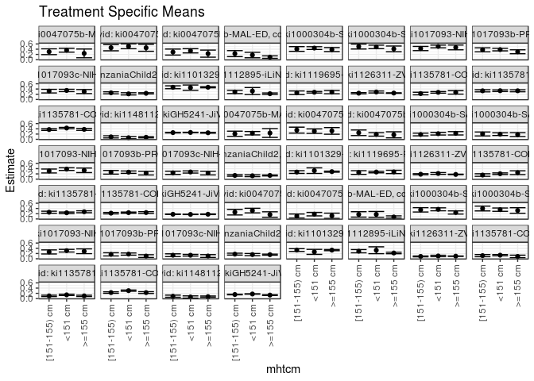

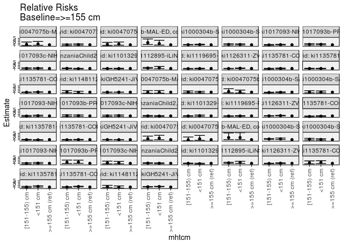

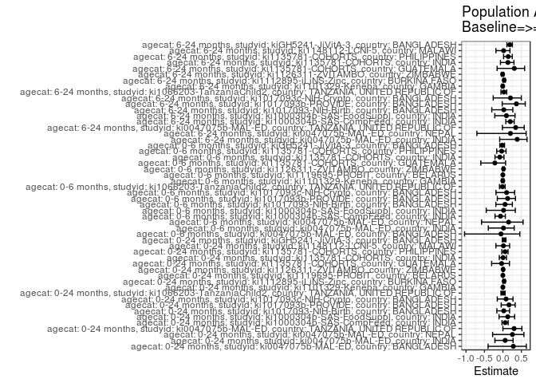

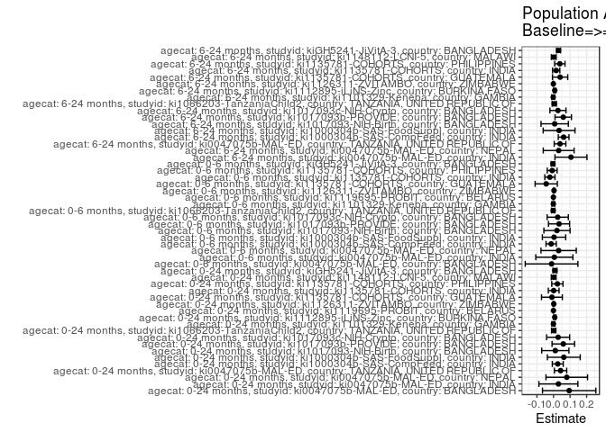

## Results Table

### Parameter: TSM

| agecat | studyid | country | intervention_level | baseline_level | estimate | ci_lower | ci_upper |
| --- | --- | --- | --- | --- | --- | --- | --- |
| 0-24 months | ki0047075b-MAL-ED | BANGLADESH | >=155 cm | NA | 0.2400000 | 0.0722560 | 0.4077440 |
| 0-24 months | ki0047075b-MAL-ED | BANGLADESH | <151 cm | NA | 0.3619632 | 0.2880425 | 0.4358839 |
| 0-24 months | ki0047075b-MAL-ED | BANGLADESH | [151-155) cm | NA | 0.3030303 | 0.1919383 | 0.4141223 |
| 0-24 months | ki0047075b-MAL-ED | INDIA | >=155 cm | NA | 0.4539463 | 0.3205210 | 0.5873716 |
| 0-24 months | ki0047075b-MAL-ED | INDIA | <151 cm | NA | 0.5111331 | 0.4187471 | 0.6035191 |
| 0-24 months | ki0047075b-MAL-ED | INDIA | [151-155) cm | NA | 0.4557666 | 0.3385210 | 0.5730123 |
| 0-24 months | ki0047075b-MAL-ED | NEPAL | >=155 cm | NA | 0.2308202 | 0.0950328 | 0.3666076 |
| 0-24 months | ki0047075b-MAL-ED | NEPAL | <151 cm | NA | 0.3388593 | 0.2578974 | 0.4198212 |
| 0-24 months | ki0047075b-MAL-ED | NEPAL | [151-155) cm | NA | 0.2909157 | 0.1765446 | 0.4052868 |
| 0-24 months | ki0047075b-MAL-ED | TANZANIA, UNITED REPUBLIC OF | >=155 cm | NA | 0.0980392 | 0.0508279 | 0.1452505 |
| 0-24 months | ki0047075b-MAL-ED | TANZANIA, UNITED REPUBLIC OF | <151 cm | NA | 0.1764706 | 0.0716399 | 0.2813013 |
| 0-24 months | ki0047075b-MAL-ED | TANZANIA, UNITED REPUBLIC OF | [151-155) cm | NA | 0.2307692 | 0.1160296 | 0.3455089 |
| 0-24 months | ki1000304b-SAS-CompFeed | INDIA | >=155 cm | NA | 0.3851952 | 0.3085134 | 0.4618770 |
| 0-24 months | ki1000304b-SAS-CompFeed | INDIA | <151 cm | NA | 0.4429161 | 0.3898464 | 0.4959858 |
| 0-24 months | ki1000304b-SAS-CompFeed | INDIA | [151-155) cm | NA | 0.4083038 | 0.3185309 | 0.4980766 |
| 0-24 months | ki1000304b-SAS-FoodSuppl | INDIA | >=155 cm | NA | 0.4121759 | 0.3023868 | 0.5219650 |
| 0-24 months | ki1000304b-SAS-FoodSuppl | INDIA | <151 cm | NA | 0.4872822 | 0.4208770 | 0.5536874 |
| 0-24 months | ki1000304b-SAS-FoodSuppl | INDIA | [151-155) cm | NA | 0.5010635 | 0.4072068 | 0.5949203 |
| 0-24 months | ki1017093-NIH-Birth | BANGLADESH | >=155 cm | NA | 0.4665871 | 0.3757463 | 0.5574278 |
| 0-24 months | ki1017093-NIH-Birth | BANGLADESH | <151 cm | NA | 0.5047406 | 0.4529422 | 0.5565389 |
| 0-24 months | ki1017093-NIH-Birth | BANGLADESH | [151-155) cm | NA | 0.4264064 | 0.3462927 | 0.5065202 |
| 0-24 months | ki1017093b-PROVIDE | BANGLADESH | >=155 cm | NA | 0.3011624 | 0.2263067 | 0.3760181 |
| 0-24 months | ki1017093b-PROVIDE | BANGLADESH | <151 cm | NA | 0.3854387 | 0.3364476 | 0.4344297 |
| 0-24 months | ki1017093b-PROVIDE | BANGLADESH | [151-155) cm | NA | 0.3756504 | 0.2989195 | 0.4523812 |
| 0-24 months | ki1017093c-NIH-Crypto | BANGLADESH | >=155 cm | NA | 0.3018489 | 0.2253153 | 0.3783825 |
| 0-24 months | ki1017093c-NIH-Crypto | BANGLADESH | <151 cm | NA | 0.3447377 | 0.2999820 | 0.3894933 |
| 0-24 months | ki1017093c-NIH-Crypto | BANGLADESH | [151-155) cm | NA | 0.3188270 | 0.2503913 | 0.3872628 |
| 0-24 months | ki1066203-TanzaniaChild2 | TANZANIA, UNITED REPUBLIC OF | >=155 cm | NA | 0.2358636 | 0.2142821 | 0.2574452 |
| 0-24 months | ki1066203-TanzaniaChild2 | TANZANIA, UNITED REPUBLIC OF | <151 cm | NA | 0.2150958 | 0.1727552 | 0.2574365 |
| 0-24 months | ki1066203-TanzaniaChild2 | TANZANIA, UNITED REPUBLIC OF | [151-155) cm | NA | 0.2553389 | 0.2174828 | 0.2931950 |

[output cut: 126 more lines]

### Parameter: E(Y)

| agecat | studyid | country | intervention_level | baseline_level | estimate | ci_lower | ci_upper |
| --- | --- | --- | --- | --- | --- | --- | --- |
| 0-24 months | ki0047075b-MAL-ED | BANGLADESH | NA | NA | 0.3346457 | 0.2765014 | 0.3927899 |
| 0-24 months | ki0047075b-MAL-ED | INDIA | NA | NA | 0.4834711 | 0.4203794 | 0.5465628 |
| 0-24 months | ki0047075b-MAL-ED | NEPAL | NA | NA | 0.3109244 | 0.2519946 | 0.3698541 |
| 0-24 months | ki0047075b-MAL-ED | TANZANIA, UNITED REPUBLIC OF | NA | NA | 0.1406250 | 0.0979572 | 0.1832928 |
| 0-24 months | ki1000304b-SAS-CompFeed | INDIA | NA | NA | 0.4107914 | 0.3512139 | 0.4703688 |
| 0-24 months | ki1000304b-SAS-FoodSuppl | INDIA | NA | NA | 0.4743276 | 0.4258753 | 0.5227800 |
| 0-24 months | ki1017093-NIH-Birth | BANGLADESH | NA | NA | 0.4775641 | 0.4383415 | 0.5167867 |
| 0-24 months | ki1017093b-PROVIDE | BANGLADESH | NA | NA | 0.3602392 | 0.3238339 | 0.3966444 |
| 0-24 months | ki1017093c-NIH-Crypto | BANGLADESH | NA | NA | 0.3298013 | 0.2962438 | 0.3633589 |
| 0-24 months | ki1066203-TanzaniaChild2 | TANZANIA, UNITED REPUBLIC OF | NA | NA | 0.2369648 | 0.2198019 | 0.2541277 |
| 0-24 months | ki1101329-Keneba | GAMBIA | NA | NA | 0.4663106 | 0.4464881 | 0.4861331 |
| 0-24 months | ki1112895-iLiNS-Zinc | BURKINA FASO | NA | NA | 0.2278520 | 0.2008644 | 0.2548397 |
| 0-24 months | ki1119695-PROBIT | BELARUS | NA | NA | 0.2816368 | 0.2197012 | 0.3435724 |
| 0-24 months | ki1126311-ZVITAMBO | ZIMBABWE | NA | NA | 0.2467955 | 0.2382720 | 0.2553190 |
| 0-24 months | ki1135781-COHORTS | GUATEMALA | NA | NA | 0.2627451 | 0.2385772 | 0.2869130 |
| 0-24 months | ki1135781-COHORTS | INDIA | NA | NA | 0.3338583 | 0.3126757 | 0.3550409 |
| 0-24 months | ki1135781-COHORTS | PHILIPPINES | NA | NA | 0.4036125 | 0.3861835 | 0.4210415 |
| 0-24 months | ki1148112-LCNI-5 | MALAWI | NA | NA | 0.0788530 | 0.0605839 | 0.0971222 |
| 0-24 months | kiGH5241-JiVitA-3 | BANGLADESH | NA | NA | 0.2580393 | 0.2515701 | 0.2645084 |
| 0-6 months | ki0047075b-MAL-ED | BANGLADESH | NA | NA | 0.2283465 | 0.1766220 | 0.2800709 |
| 0-6 months | ki0047075b-MAL-ED | INDIA | NA | NA | 0.3264463 | 0.2672449 | 0.3856476 |
| 0-6 months | ki0047075b-MAL-ED | NEPAL | NA | NA | 0.2016807 | 0.1505956 | 0.2527658 |
| 0-6 months | ki1000304b-SAS-CompFeed | INDIA | NA | NA | 0.2154736 | 0.1691818 | 0.2617655 |
| 0-6 months | ki1000304b-SAS-FoodSuppl | INDIA | NA | NA | 0.1833741 | 0.1458251 | 0.2209231 |
| 0-6 months | ki1017093-NIH-Birth | BANGLADESH | NA | NA | 0.3569132 | 0.3192325 | 0.3945938 |
| 0-6 months | ki1017093b-PROVIDE | BANGLADESH | NA | NA | 0.2630792 | 0.2296894 | 0.2964690 |
| 0-6 months | ki1017093c-NIH-Crypto | BANGLADESH | NA | NA | 0.2569536 | 0.2257649 | 0.2881424 |
| 0-6 months | ki1066203-TanzaniaChild2 | TANZANIA, UNITED REPUBLIC OF | NA | NA | 0.1394659 | 0.1254831 | 0.1534487 |
| 0-6 months | ki1101329-Keneba | GAMBIA | NA | NA | 0.2843909 | 0.2653574 | 0.3034244 |
| 0-6 months | ki1119695-PROBIT | BELARUS | NA | NA | 0.2746469 | 0.2119817 | 0.3373120 |
| 0-6 months | ki1126311-ZVITAMBO | ZIMBABWE | NA | NA | 0.1822917 | 0.1746442 | 0.1899391 |
| 0-6 months | ki1135781-COHORTS | GUATEMALA | NA | NA | 0.2019139 | 0.1775635 | 0.2262643 |
| 0-6 months | ki1135781-COHORTS | INDIA | NA | NA | 0.2528180 | 0.2330767 | 0.2725593 |
| 0-6 months | ki1135781-COHORTS | PHILIPPINES | NA | NA | 0.2355453 | 0.2204685 | 0.2506222 |
| 0-6 months | kiGH5241-JiVitA-3 | BANGLADESH | NA | NA | 0.1762154 | 0.1705946 | 0.1818362 |
| 6-24 months | ki0047075b-MAL-ED | INDIA | NA | NA | 0.2735043 | 0.2162683 | 0.3307402 |
| 6-24 months | ki0047075b-MAL-ED | NEPAL | NA | NA | 0.1531915 | 0.1070438 | 0.1993392 |
| 6-24 months | ki0047075b-MAL-ED | TANZANIA, UNITED REPUBLIC OF | NA | NA | 0.1142857 | 0.0743652 | 0.1542062 |
| 6-24 months | ki1000304b-SAS-CompFeed | INDIA | NA | NA | 0.3077525 | 0.2591695 | 0.3563356 |
| 6-24 months | ki1000304b-SAS-FoodSuppl | INDIA | NA | NA | 0.3566085 | 0.3096676 | 0.4035494 |
| 6-24 months | ki1017093-NIH-Birth | BANGLADESH | NA | NA | 0.2933579 | 0.2549918 | 0.3317241 |
| 6-24 months | ki1017093b-PROVIDE | BANGLADESH | NA | NA | 0.1612378 | 0.1321259 | 0.1903497 |
| 6-24 months | ki1017093c-NIH-Crypto | BANGLADESH | NA | NA | 0.1315068 | 0.1069744 | 0.1560393 |
| 6-24 months | ki1066203-TanzaniaChild2 | TANZANIA, UNITED REPUBLIC OF | NA | NA | 0.1617128 | 0.1455117 | 0.1779140 |
| 6-24 months | ki1101329-Keneba | GAMBIA | NA | NA | 0.3284609 | 0.3093705 | 0.3475512 |
| 6-24 months | ki1112895-iLiNS-Zinc | BURKINA FASO | NA | NA | 0.2278520 | 0.2008644 | 0.2548397 |
| 6-24 months | ki1126311-ZVITAMBO | ZIMBABWE | NA | NA | 0.0985622 | 0.0922708 | 0.1048535 |
| 6-24 months | ki1135781-COHORTS | GUATEMALA | NA | NA | 0.1288927 | 0.1095683 | 0.1482172 |
| 6-24 months | ki1135781-COHORTS | INDIA | NA | NA | 0.1199132 | 0.1050778 | 0.1347486 |
| 6-24 months | ki1135781-COHORTS | PHILIPPINES | NA | NA | 0.2666429 | 0.2502871 | 0.2829988 |
| 6-24 months | ki1148112-LCNI-5 | MALAWI | NA | NA | 0.0765492 | 0.0583736 | 0.0947248 |
| 6-24 months | kiGH5241-JiVitA-3 | BANGLADESH | NA | NA | 0.1637386 | 0.1576238 | 0.1698535 |

### Parameter: RR

| agecat | studyid | country | intervention_level | baseline_level | estimate | ci_lower | ci_upper |
| --- | --- | --- | --- | --- | --- | --- | --- |
| 0-24 months | ki0047075b-MAL-ED | BANGLADESH | >=155 cm | >=155 cm | 1.0000000 | 1.0000000 | 1.0000000 |
| 0-24 months | ki0047075b-MAL-ED | BANGLADESH | <151 cm | >=155 cm | 1.5081800 | 0.7281453 | 3.1238365 |
| 0-24 months | ki0047075b-MAL-ED | BANGLADESH | [151-155) cm | >=155 cm | 1.2626263 | 0.5734697 | 2.7799639 |
| 0-24 months | ki0047075b-MAL-ED | INDIA | >=155 cm | >=155 cm | 1.0000000 | 1.0000000 | 1.0000000 |
| 0-24 months | ki0047075b-MAL-ED | INDIA | <151 cm | >=155 cm | 1.1259770 | 0.7966150 | 1.5915145 |
| 0-24 months | ki0047075b-MAL-ED | INDIA | [151-155) cm | >=155 cm | 1.0040100 | 0.6791595 | 1.4842406 |
| 0-24 months | ki0047075b-MAL-ED | NEPAL | >=155 cm | >=155 cm | 1.0000000 | 1.0000000 | 1.0000000 |
| 0-24 months | ki0047075b-MAL-ED | NEPAL | <151 cm | >=155 cm | 1.4680660 | 0.7786642 | 2.7678398 |
| 0-24 months | ki0047075b-MAL-ED | NEPAL | [151-155) cm | >=155 cm | 1.2603562 | 0.6212440 | 2.5569625 |
| 0-24 months | ki0047075b-MAL-ED | TANZANIA, UNITED REPUBLIC OF | >=155 cm | >=155 cm | 1.0000000 | 1.0000000 | 1.0000000 |
| 0-24 months | ki0047075b-MAL-ED | TANZANIA, UNITED REPUBLIC OF | <151 cm | >=155 cm | 1.8000000 | 0.8378448 | 3.8670647 |
| 0-24 months | ki0047075b-MAL-ED | TANZANIA, UNITED REPUBLIC OF | [151-155) cm | >=155 cm | 2.3538461 | 1.1780658 | 4.7031256 |
| 0-24 months | ki1000304b-SAS-CompFeed | INDIA | >=155 cm | >=155 cm | 1.0000000 | 1.0000000 | 1.0000000 |
| 0-24 months | ki1000304b-SAS-CompFeed | INDIA | <151 cm | >=155 cm | 1.1498485 | 0.9476524 | 1.3951863 |
| 0-24 months | ki1000304b-SAS-CompFeed | INDIA | [151-155) cm | >=155 cm | 1.0599919 | 0.9232199 | 1.2170262 |
| 0-24 months | ki1000304b-SAS-FoodSuppl | INDIA | >=155 cm | >=155 cm | 1.0000000 | 1.0000000 | 1.0000000 |
| 0-24 months | ki1000304b-SAS-FoodSuppl | INDIA | <151 cm | >=155 cm | 1.1822191 | 0.8766657 | 1.5942703 |
| 0-24 months | ki1000304b-SAS-FoodSuppl | INDIA | [151-155) cm | >=155 cm | 1.2156547 | 0.8780172 | 1.6831291 |
| 0-24 months | ki1017093-NIH-Birth | BANGLADESH | >=155 cm | >=155 cm | 1.0000000 | 1.0000000 | 1.0000000 |
| 0-24 months | ki1017093-NIH-Birth | BANGLADESH | <151 cm | >=155 cm | 1.0817715 | 0.8681103 | 1.3480194 |
| 0-24 months | ki1017093-NIH-Birth | BANGLADESH | [151-155) cm | >=155 cm | 0.9138840 | 0.6968054 | 1.1985901 |
| 0-24 months | ki1017093b-PROVIDE | BANGLADESH | >=155 cm | >=155 cm | 1.0000000 | 1.0000000 | 1.0000000 |
| 0-24 months | ki1017093b-PROVIDE | BANGLADESH | <151 cm | >=155 cm | 1.2798367 | 0.9686574 | 1.6909820 |
| 0-24 months | ki1017093b-PROVIDE | BANGLADESH | [151-155) cm | >=155 cm | 1.2473349 | 0.9046282 | 1.7198717 |
| 0-24 months | ki1017093c-NIH-Crypto | BANGLADESH | >=155 cm | >=155 cm | 1.0000000 | 1.0000000 | 1.0000000 |
| 0-24 months | ki1017093c-NIH-Crypto | BANGLADESH | <151 cm | >=155 cm | 1.1420869 | 0.8588363 | 1.5187556 |
| 0-24 months | ki1017093c-NIH-Crypto | BANGLADESH | [151-155) cm | >=155 cm | 1.0562472 | 0.7576220 | 1.4725787 |
| 0-24 months | ki1066203-TanzaniaChild2 | TANZANIA, UNITED REPUBLIC OF | >=155 cm | >=155 cm | 1.0000000 | 1.0000000 | 1.0000000 |
| 0-24 months | ki1066203-TanzaniaChild2 | TANZANIA, UNITED REPUBLIC OF | <151 cm | >=155 cm | 0.9119500 | 0.7339243 | 1.1331589 |
| 0-24 months | ki1066203-TanzaniaChild2 | TANZANIA, UNITED REPUBLIC OF | [151-155) cm | >=155 cm | 1.0825700 | 0.9096548 | 1.2883544 |

[output cut: 126 more lines]

### Parameter: PAR

| agecat | studyid | country | intervention_level | baseline_level | estimate | ci_lower | ci_upper |
| --- | --- | --- | --- | --- | --- | --- | --- |
| 0-24 months | ki0047075b-MAL-ED | BANGLADESH | >=155 cm | NA | 0.0946457 | -0.0665369 | 0.2558283 |
| 0-24 months | ki0047075b-MAL-ED | INDIA | >=155 cm | NA | 0.0295248 | -0.0881175 | 0.1471671 |
| 0-24 months | ki0047075b-MAL-ED | NEPAL | >=155 cm | NA | 0.0801042 | -0.0453943 | 0.2056026 |
| 0-24 months | ki0047075b-MAL-ED | TANZANIA, UNITED REPUBLIC OF | >=155 cm | NA | 0.0425858 | 0.0053674 | 0.0798042 |
| 0-24 months | ki1000304b-SAS-CompFeed | INDIA | >=155 cm | NA | 0.0255962 | -0.0074106 | 0.0586030 |
| 0-24 months | ki1000304b-SAS-FoodSuppl | INDIA | >=155 cm | NA | 0.0621517 | -0.0369895 | 0.1612930 |
| 0-24 months | ki1017093-NIH-Birth | BANGLADESH | >=155 cm | NA | 0.0109770 | -0.0711386 | 0.0930927 |
| 0-24 months | ki1017093b-PROVIDE | BANGLADESH | >=155 cm | NA | 0.0590768 | -0.0088076 | 0.1269611 |
| 0-24 months | ki1017093c-NIH-Crypto | BANGLADESH | >=155 cm | NA | 0.0279524 | -0.0415529 | 0.0974578 |
| 0-24 months | ki1066203-TanzaniaChild2 | TANZANIA, UNITED REPUBLIC OF | >=155 cm | NA | 0.0011012 | -0.0120127 | 0.0142151 |
| 0-24 months | ki1101329-Keneba | GAMBIA | >=155 cm | NA | -0.0006520 | -0.0097089 | 0.0084049 |
| 0-24 months | ki1112895-iLiNS-Zinc | BURKINA FASO | >=155 cm | NA | 0.0074110 | 0.0008649 | 0.0139571 |
| 0-24 months | ki1119695-PROBIT | BELARUS | >=155 cm | NA | -0.0004648 | -0.0019207 | 0.0009911 |
| 0-24 months | ki1126311-ZVITAMBO | ZIMBABWE | >=155 cm | NA | 0.0015348 | -0.0028159 | 0.0058855 |
| 0-24 months | ki1135781-COHORTS | GUATEMALA | >=155 cm | NA | -0.0095184 | -0.0724640 | 0.0534271 |
| 0-24 months | ki1135781-COHORTS | INDIA | >=155 cm | NA | 0.0011570 | -0.0312421 | 0.0335560 |
| 0-24 months | ki1135781-COHORTS | PHILIPPINES | >=155 cm | NA | 0.0233982 | -0.0105662 | 0.0573626 |
| 0-24 months | ki1148112-LCNI-5 | MALAWI | >=155 cm | NA | 0.0010320 | -0.0135015 | 0.0155656 |
| 0-24 months | kiGH5241-JiVitA-3 | BANGLADESH | >=155 cm | NA | 0.0086517 | -0.0037769 | 0.0210804 |
| 0-6 months | ki0047075b-MAL-ED | BANGLADESH | >=155 cm | NA | -0.0116535 | -0.1706331 | 0.1473260 |
| 0-6 months | ki0047075b-MAL-ED | INDIA | >=155 cm | NA | 0.0050911 | -0.1069528 | 0.1171350 |
| 0-6 months | ki0047075b-MAL-ED | NEPAL | >=155 cm | NA | 0.0309490 | -0.0755469 | 0.1374448 |
| 0-6 months | ki1000304b-SAS-CompFeed | INDIA | >=155 cm | NA | -0.0140913 | -0.0449985 | 0.0168158 |
| 0-6 months | ki1000304b-SAS-FoodSuppl | INDIA | >=155 cm | NA | 0.0031995 | -0.0672633 | 0.0736623 |
| 0-6 months | ki1017093-NIH-Birth | BANGLADESH | >=155 cm | NA | 0.0209211 | -0.0581278 | 0.0999699 |
| 0-6 months | ki1017093b-PROVIDE | BANGLADESH | >=155 cm | NA | 0.0335309 | -0.0302741 | 0.0973359 |
| 0-6 months | ki1017093c-NIH-Crypto | BANGLADESH | >=155 cm | NA | 0.0254467 | -0.0385893 | 0.0894827 |
| 0-6 months | ki1066203-TanzaniaChild2 | TANZANIA, UNITED REPUBLIC OF | >=155 cm | NA | -0.0018911 | -0.0125152 | 0.0087329 |
| 0-6 months | ki1101329-Keneba | GAMBIA | >=155 cm | NA | -0.0010956 | -0.0096535 | 0.0074623 |
| 0-6 months | ki1119695-PROBIT | BELARUS | >=155 cm | NA | -0.0005589 | -0.0020558 | 0.0009379 |
| 0-6 months | ki1126311-ZVITAMBO | ZIMBABWE | >=155 cm | NA | 0.0029330 | -0.0010281 | 0.0068942 |
| 0-6 months | ki1135781-COHORTS | GUATEMALA | >=155 cm | NA | -0.0439861 | -0.1110075 | 0.0230354 |
| 0-6 months | ki1135781-COHORTS | INDIA | >=155 cm | NA | -0.0217518 | -0.0525786 | 0.0090751 |
| 0-6 months | ki1135781-COHORTS | PHILIPPINES | >=155 cm | NA | -0.0080660 | -0.0378129 | 0.0216809 |
| 0-6 months | kiGH5241-JiVitA-3 | BANGLADESH | >=155 cm | NA | -0.0031985 | -0.0144784 | 0.0080814 |
| 6-24 months | ki0047075b-MAL-ED | INDIA | >=155 cm | NA | 0.1055767 | 0.0091154 | 0.2020379 |
| 6-24 months | ki0047075b-MAL-ED | NEPAL | >=155 cm | NA | 0.0312403 | -0.0619769 | 0.1244574 |
| 6-24 months | ki0047075b-MAL-ED | TANZANIA, UNITED REPUBLIC OF | >=155 cm | NA | 0.0394558 | 0.0043797 | 0.0745319 |
| 6-24 months | ki1000304b-SAS-CompFeed | INDIA | >=155 cm | NA | 0.0611969 | 0.0288456 | 0.0935481 |
| 6-24 months | ki1000304b-SAS-FoodSuppl | INDIA | >=155 cm | NA | 0.0336989 | -0.0624020 | 0.1297998 |
| 6-24 months | ki1017093-NIH-Birth | BANGLADESH | >=155 cm | NA | 0.0071114 | -0.0754220 | 0.0896448 |
| 6-24 months | ki1017093b-PROVIDE | BANGLADESH | >=155 cm | NA | 0.0588408 | 0.0093798 | 0.1083017 |
| 6-24 months | ki1017093c-NIH-Crypto | BANGLADESH | >=155 cm | NA | 0.0268579 | -0.0215785 | 0.0752944 |
| 6-24 months | ki1066203-TanzaniaChild2 | TANZANIA, UNITED REPUBLIC OF | >=155 cm | NA | 0.0044752 | -0.0081280 | 0.0170784 |
| 6-24 months | ki1101329-Keneba | GAMBIA | >=155 cm | NA | -0.0018527 | -0.0105727 | 0.0068673 |
| 6-24 months | ki1112895-iLiNS-Zinc | BURKINA FASO | >=155 cm | NA | 0.0075330 | 0.0009408 | 0.0141251 |
| 6-24 months | ki1126311-ZVITAMBO | ZIMBABWE | >=155 cm | NA | -0.0008699 | -0.0040377 | 0.0022978 |
| 6-24 months | ki1135781-COHORTS | GUATEMALA | >=155 cm | NA | 0.0398136 | -0.0063326 | 0.0859598 |
| 6-24 months | ki1135781-COHORTS | INDIA | >=155 cm | NA | 0.0162847 | -0.0055862 | 0.0381557 |
| 6-24 months | ki1135781-COHORTS | PHILIPPINES | >=155 cm | NA | 0.0383003 | 0.0072413 | 0.0693593 |
| 6-24 months | ki1148112-LCNI-5 | MALAWI | >=155 cm | NA | 0.0014504 | -0.0130102 | 0.0159110 |
| 6-24 months | kiGH5241-JiVitA-3 | BANGLADESH | >=155 cm | NA | 0.0303613 | 0.0181724 | 0.0425502 |

### Parameter: PAF

| agecat | studyid | country | intervention_level | baseline_level | estimate | ci_lower | ci_upper |
| --- | --- | --- | --- | --- | --- | --- | --- |
| 0-24 months | ki0047075b-MAL-ED | BANGLADESH | >=155 cm | NA | 0.2828235 | -0.4024019 | 0.6332420 |
| 0-24 months | ki0047075b-MAL-ED | INDIA | >=155 cm | NA | 0.0610684 | -0.2168564 | 0.2755163 |
| 0-24 months | ki0047075b-MAL-ED | NEPAL | >=155 cm | NA | 0.2576323 | -0.2792657 | 0.5691983 |
| 0-24 months | ki0047075b-MAL-ED | TANZANIA, UNITED REPUBLIC OF | >=155 cm | NA | 0.3028322 | -0.0008100 | 0.5143505 |
| 0-24 months | ki1000304b-SAS-CompFeed | INDIA | >=155 cm | NA | 0.0623095 | -0.0251762 | 0.1423294 |
| 0-24 months | ki1000304b-SAS-FoodSuppl | INDIA | >=155 cm | NA | 0.1310313 | -0.1055899 | 0.3170102 |
| 0-24 months | ki1017093-NIH-Birth | BANGLADESH | >=155 cm | NA | 0.0229855 | -0.1650223 | 0.1806531 |
| 0-24 months | ki1017093b-PROVIDE | BANGLADESH | >=155 cm | NA | 0.1639932 | -0.0469027 | 0.3324046 |
| 0-24 months | ki1017093c-NIH-Crypto | BANGLADESH | >=155 cm | NA | 0.0847553 | -0.1522228 | 0.2729941 |
| 0-24 months | ki1066203-TanzaniaChild2 | TANZANIA, UNITED REPUBLIC OF | >=155 cm | NA | 0.0046471 | -0.0522621 | 0.0584784 |
| 0-24 months | ki1101329-Keneba | GAMBIA | >=155 cm | NA | -0.0013982 | -0.0210104 | 0.0178373 |
| 0-24 months | ki1112895-iLiNS-Zinc | BURKINA FASO | >=155 cm | NA | 0.0325256 | 0.0023649 | 0.0617744 |
| 0-24 months | ki1119695-PROBIT | BELARUS | >=155 cm | NA | -0.0016503 | -0.0067645 | 0.0034379 |
| 0-24 months | ki1126311-ZVITAMBO | ZIMBABWE | >=155 cm | NA | 0.0062188 | -0.0115669 | 0.0236918 |
| 0-24 months | ki1135781-COHORTS | GUATEMALA | >=155 cm | NA | -0.0362269 | -0.3057553 | 0.1776666 |
| 0-24 months | ki1135781-COHORTS | INDIA | >=155 cm | NA | 0.0034654 | -0.0984616 | 0.0959346 |
| 0-24 months | ki1135781-COHORTS | PHILIPPINES | >=155 cm | NA | 0.0579719 | -0.0300592 | 0.1384797 |
| 0-24 months | ki1148112-LCNI-5 | MALAWI | >=155 cm | NA | 0.0130881 | -0.1895327 | 0.1811952 |
| 0-24 months | kiGH5241-JiVitA-3 | BANGLADESH | >=155 cm | NA | 0.0335287 | -0.0159249 | 0.0805750 |
| 0-6 months | ki0047075b-MAL-ED | BANGLADESH | >=155 cm | NA | -0.0510345 | -1.0383796 | 0.4580629 |
| 0-6 months | ki0047075b-MAL-ED | INDIA | >=155 cm | NA | 0.0155956 | -0.3951009 | 0.3053892 |
| 0-6 months | ki0047075b-MAL-ED | NEPAL | >=155 cm | NA | 0.1534553 | -0.5780681 | 0.5458764 |
| 0-6 months | ki1000304b-SAS-CompFeed | INDIA | >=155 cm | NA | -0.0653971 | -0.2142443 | 0.0652038 |
| 0-6 months | ki1000304b-SAS-FoodSuppl | INDIA | >=155 cm | NA | 0.0174478 | -0.4520686 | 0.3351494 |
| 0-6 months | ki1017093-NIH-Birth | BANGLADESH | >=155 cm | NA | 0.0586167 | -0.1911558 | 0.2560146 |
| 0-6 months | ki1017093b-PROVIDE | BANGLADESH | >=155 cm | NA | 0.1274554 | -0.1521303 | 0.3391945 |
| 0-6 months | ki1017093c-NIH-Crypto | BANGLADESH | >=155 cm | NA | 0.0990322 | -0.1879140 | 0.3166653 |
| 0-6 months | ki1066203-TanzaniaChild2 | TANZANIA, UNITED REPUBLIC OF | >=155 cm | NA | -0.0135598 | -0.0926615 | 0.0598155 |
| 0-6 months | ki1101329-Keneba | GAMBIA | >=155 cm | NA | -0.0038524 | -0.0344004 | 0.0257934 |
| 0-6 months | ki1119695-PROBIT | BELARUS | >=155 cm | NA | -0.0020351 | -0.0074218 | 0.0033228 |
| 0-6 months | ki1126311-ZVITAMBO | ZIMBABWE | >=155 cm | NA | 0.0160898 | -0.0058747 | 0.0375747 |
| 0-6 months | ki1135781-COHORTS | GUATEMALA | >=155 cm | NA | -0.2178457 | -0.5988726 | 0.0723788 |
| 0-6 months | ki1135781-COHORTS | INDIA | >=155 cm | NA | -0.0860372 | -0.2150073 | 0.0292430 |
| 0-6 months | ki1135781-COHORTS | PHILIPPINES | >=155 cm | NA | -0.0342440 | -0.1685635 | 0.0846363 |
| 0-6 months | kiGH5241-JiVitA-3 | BANGLADESH | >=155 cm | NA | -0.0181511 | -0.0841815 | 0.0438579 |
| 6-24 months | ki0047075b-MAL-ED | INDIA | >=155 cm | NA | 0.3860147 | -0.0873101 | 0.6532931 |
| 6-24 months | ki0047075b-MAL-ED | NEPAL | >=155 cm | NA | 0.2039295 | -0.7049484 | 0.6283007 |
| 6-24 months | ki0047075b-MAL-ED | TANZANIA, UNITED REPUBLIC OF | >=155 cm | NA | 0.3452381 | -0.0142598 | 0.5773143 |
| 6-24 months | ki1000304b-SAS-CompFeed | INDIA | >=155 cm | NA | 0.1988508 | 0.0777376 | 0.3040592 |
| 6-24 months | ki1000304b-SAS-FoodSuppl | INDIA | >=155 cm | NA | 0.0944983 | -0.2193256 | 0.3275518 |
| 6-24 months | ki1017093-NIH-Birth | BANGLADESH | >=155 cm | NA | 0.0242414 | -0.3018788 | 0.2686686 |
| 6-24 months | ki1017093b-PROVIDE | BANGLADESH | >=155 cm | NA | 0.3649317 | -0.0201695 | 0.6046620 |
| 6-24 months | ki1017093c-NIH-Crypto | BANGLADESH | >=155 cm | NA | 0.2042323 | -0.2629086 | 0.4985811 |
| 6-24 months | ki1066203-TanzaniaChild2 | TANZANIA, UNITED REPUBLIC OF | >=155 cm | NA | 0.0276737 | -0.0534431 | 0.1025444 |
| 6-24 months | ki1101329-Keneba | GAMBIA | >=155 cm | NA | -0.0056405 | -0.0325446 | 0.0205626 |
| 6-24 months | ki1112895-iLiNS-Zinc | BURKINA FASO | >=155 cm | NA | 0.0330608 | 0.0026580 | 0.0625367 |
| 6-24 months | ki1126311-ZVITAMBO | ZIMBABWE | >=155 cm | NA | -0.0088263 | -0.0414779 | 0.0228016 |
| 6-24 months | ki1135781-COHORTS | GUATEMALA | >=155 cm | NA | 0.3088892 | -0.1578170 | 0.5874701 |
| 6-24 months | ki1135781-COHORTS | INDIA | >=155 cm | NA | 0.1358043 | -0.0662494 | 0.2995690 |
| 6-24 months | ki1135781-COHORTS | PHILIPPINES | >=155 cm | NA | 0.1436389 | 0.0190102 | 0.2524343 |
| 6-24 months | ki1148112-LCNI-5 | MALAWI | >=155 cm | NA | 0.0189472 | -0.1893171 | 0.1907419 |
| 6-24 months | kiGH5241-JiVitA-3 | BANGLADESH | >=155 cm | NA | 0.1854254 | 0.1073376 | 0.2566822 |